# Hockey Match Report

Analyst’s Diary Match Report

# Finland vs Great Britain

**22 May 2026**  
IIHF World Championship 2026 – Group Stage

Finland (FIN) 4:0 Great Britain (GB)

Report generated from the match shot-location pipeline. Metrics marked as proxies are based on OCR-extracted shot coordinates and should be interpreted as transparent spatial indicators rather than official tracking data.

Prepared by Antonin Kremenak

[figure not shown]

# Executive summary

- Finland generated the higher official shots-on-goal volume.
- Finland produced the stronger location-based Shot Quality Index.
- Finland got more attempts from the inner-slot / high-danger area.
- Finland led in high-danger chances based on the distance-and-lane proxy.

Shots On Goal

FIN: 49 | GB: 9

Blocked Shots

FIN: 29 | GB: 3

Scoring Chances

FIN: 37 | GB: 0

# 1. Public layer: simple match metrics

These visuals are designed as a simple entry point for wider audiences: official shots on goal, blocked shots, shot quality proxies and basic chance creation.

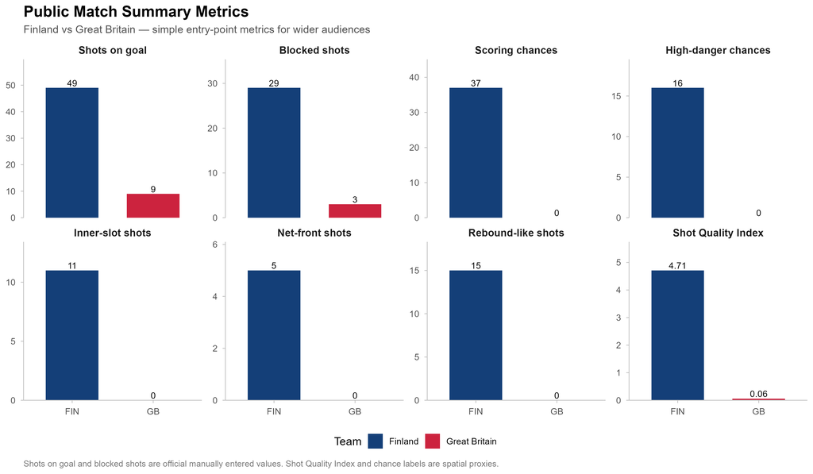

Key Metrics: Finland vs Great Britain

22 May 2026 — Shot Quality Index is a location-based proxy, not a trained xG model.

| Metric | FIN | GB |
| --- | --- | --- |
| OCR detected attempts | 55.00 | 3.00 |
| Corsi attempts | 55.00 | 3.00 |
| Fenwick attempts | 41.00 | 2.00 |
| Scoring chances | 37.00 | 0.00 |
| High-danger chances | 16.00 | 0.00 |
| Shot Quality Index | 4.71 | 0.06 |

# 2. Shot maps and spatial overview

Shot maps show where attempts came from, how dangerous they were spatially, and how shot locations changed across periods.

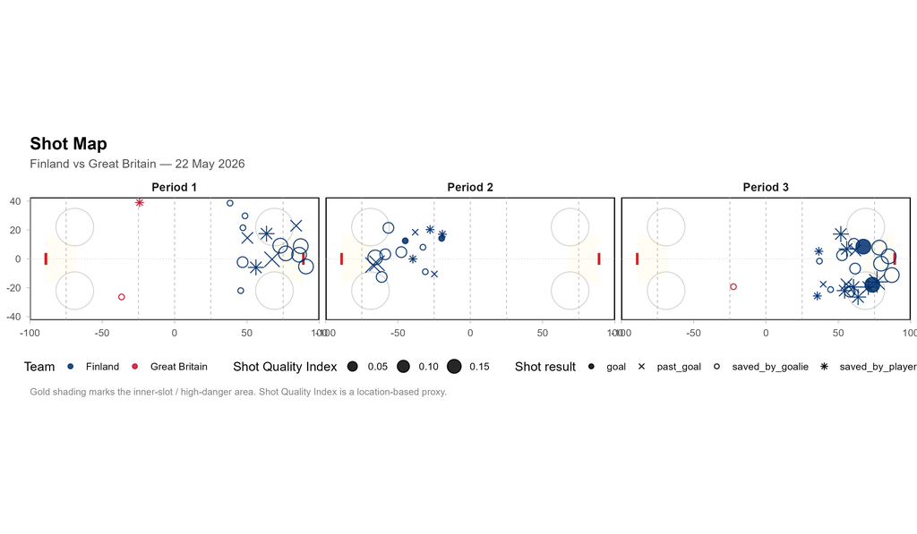

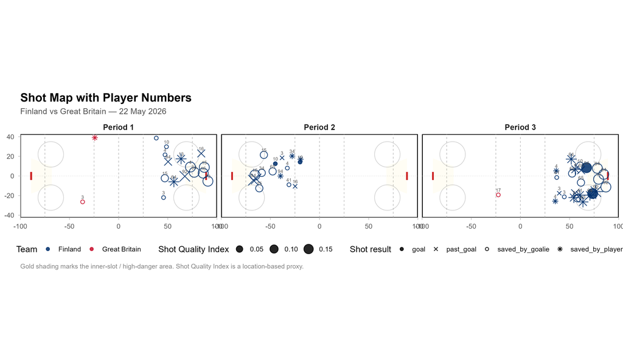

# 3. Shot quality and territorial battle

This section moves from simple shot counts to spatial pressure: location quality, offensive-zone density and period-by-period territorial advantage.

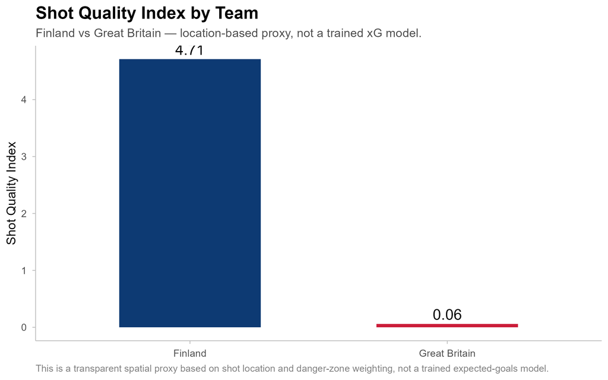

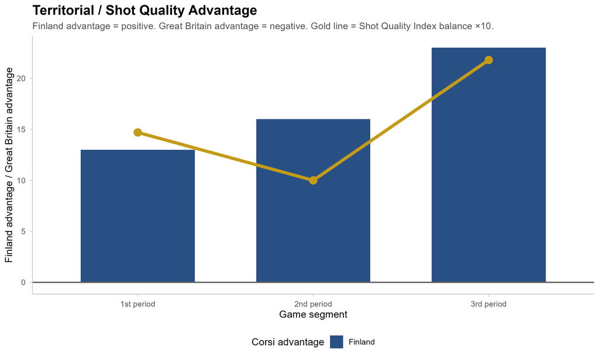

# 4. Offensive-zone density

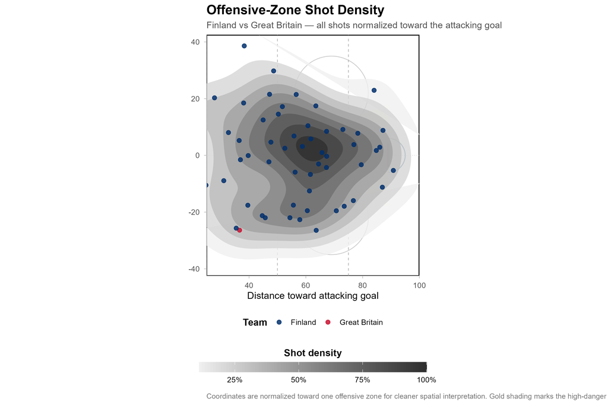

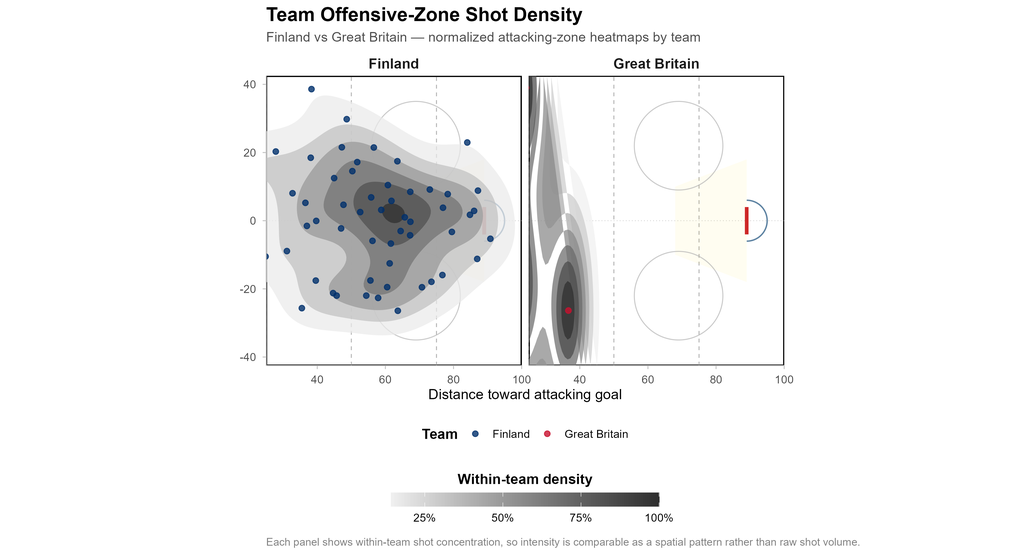

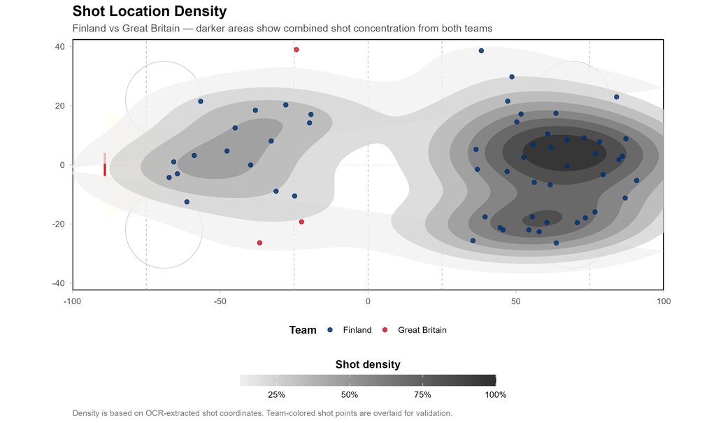

# 5. Advanced insider layer

The following metrics are proxy-based insider indicators built from the available shot-location sample. They are useful for storytelling, but they are not a substitute for full play-by-play or tracking data.

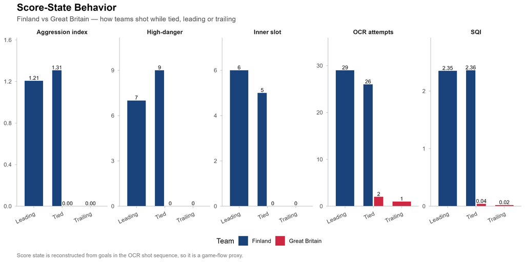

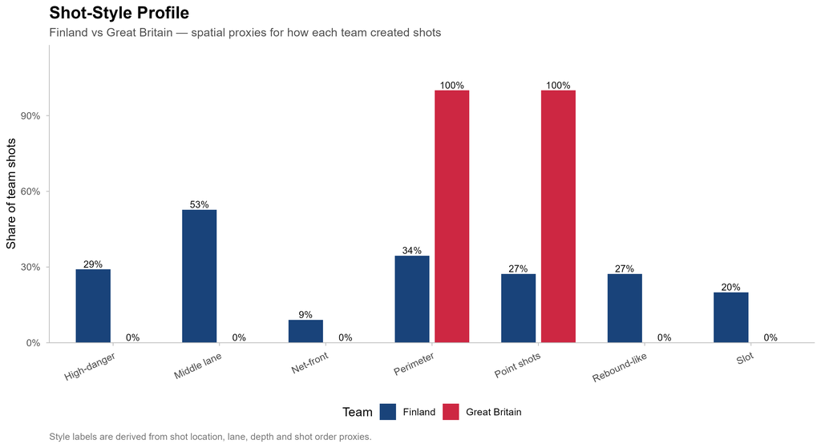

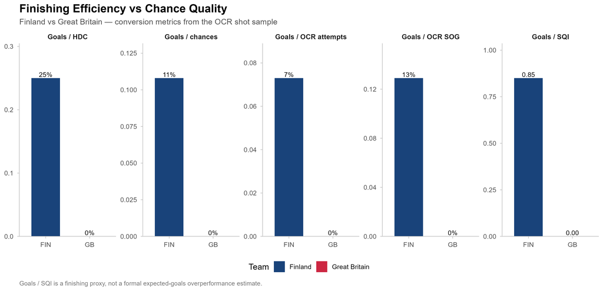

# 6. Momentum

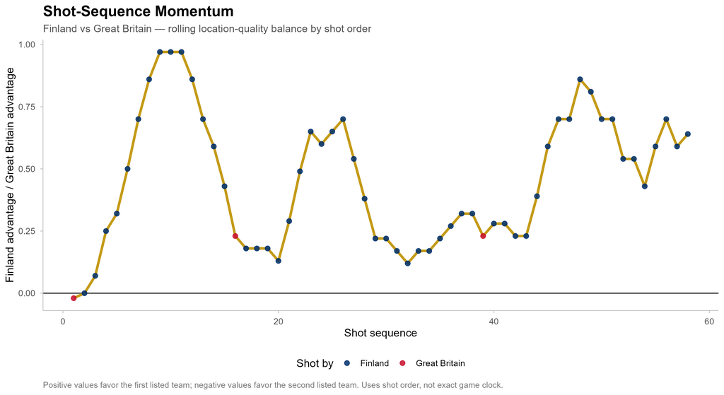

# 7. Player layer

**Player public leaders**

Top players from the OCR-extracted shot sample

| Team | Player no. | OCR attempts | OCR shots on goal | Scoring chances | High-danger chances | Inner-slot shots | Net-front shots | Rebound-like shots | Shot Quality Index | Avg shot distance |
| --- | --- | --- | --- | --- | --- | --- | --- | --- | --- | --- |
| Finland | 16 | 5 | 3 | 4 | 3 | 2 | 1 | 2 | 0.63 | 25.2 |
| Finland | 94 | 5 | 1 | 4 | 3 | 1 | 0 | 2 | 0.63 | 30.1 |
| Finland | 64 | 5 | 2 | 5 | 2 | 2 | 1 | 2 | 0.57 | 23.7 |
| Finland | 92 | 3 | 1 | 3 | 3 | 2 | 1 | 2 | 0.54 | 17.7 |
| Finland | 15 | 4 | 4 | 4 | 1 | 1 | 1 | 1 | 0.39 | 30.1 |
| Finland | 4 | 6 | 3 | 2 | 1 | 1 | 0 | 2 | 0.33 | 44.7 |
| Finland | 10 | 5 | 5 | 2 | 1 | 1 | 0 | 2 | 0.31 | 44.1 |
| Finland | 65 | 3 | 2 | 3 | 0 | 0 | 0 | 0 | 0.21 | 32.5 |
| Finland | 04 | 1 | 1 | 1 | 1 | 0 | 0 | 1 | 0.18 | 23.3 |
| Finland | 73 | 1 | 1 | 1 | 1 | 1 | 1 | 0 | 0.18 | 5.6 |
| Finland | 34 | 3 | 1 | 2 | 0 | 0 | 0 | 0 | 0.16 | 44.2 |
| Finland | 3 | 5 | 2 | 1 | 0 | 0 | 0 | 0 | 0.15 | 49.1 |

*Player-level statistics are generated from OCR-detected shot markers and spatial coordinates from IIHF shot charts. Due to OCR limitations and embedded IIHF PDF fonts, some player-level counts may contain minor inaccuracies.*

[output not shown]